# lesson08.R

jonkq

2019-12-12

## Assignment Set 3: Lesson 8

Add R Code under the questions. If you are done, ‘knit’ the document, commit and push to GitHub. You can use GitHub Pages if you like, add links to README.md to make it easier to find the pretty version.

```r
library(dplyr)
library(nycflights13)
```

```r
library(ggplot2)
airlines <- airlines
airports <- airports
flights <- flights
planes <- planes
weather <- weather
```

1. Joins: Flattening

From all 5 datasets in the {nycflights13} package, create one wide table that contains the data from the `flights` table with the following details:

- Name of the airline
- Name, latitute and longitude of the origin and destination airports (if available)
- Manufacturer, model and seats for the airplane used (if available)
- Temperature and humidity at the airport of origin during departure time

The data you create must contain one row for each observation in `flights`. Ensure that the columns are named in a way that allows to uniquely define the purpose. Hint: Implement this as a sequence of `left_join()` operations. For `weather` use the `time_hour` column.

```r
flights_wide <- flights %>%
  left_join(airlines) %>%
  left_join(weather) %>%
  left_join(planes) %>%
  left_join(airports) %>%
  select(colnames(flights), lat, lon, manufacturer, model, seats, temp, humid)
flights_wide
```

```
## # A tibble: 336,776 x 26
##     year month   day dep_time sched_dep_time dep_delay arr_time
##    <int> <int> <int>    <int>          <int>     <dbl>    <int>
##  1  2013     1     1      517            515         2      830
##  2  2013     1     1      533            529         4      850
##  3  2013     1     1      542            540         2      923
##  4  2013     1     1      544            545        -1     1004
##  5  2013     1     1      554            600        -6      812
##  6  2013     1     1      554            558        -4      740
##  7  2013     1     1      555            600        -5      913
##  8  2013     1     1      557            600        -3      709
##  9  2013     1     1      557            600        -3      838
## 10  2013     1     1      558            600        -2      753
## # ... with 336,766 more rows, and 19 more variables: sched_arr_time <int>,
## #   arr_delay <dbl>, carrier <chr>, flight <int>, tailnum <chr>,
## #   origin <chr>, dest <chr>, air_time <dbl>, distance <dbl>, hour <dbl>,
## #   minute <dbl>, time_hour <dttm>, lat <dbl>, lon <dbl>,
## #   manufacturer <chr>, model <chr>, seats <int>, temp <dbl>, humid <dbl>
```

2. Joins: Filtering

Reduce the result of the first exercise from this lesson to exclude all flights where no detailed information on the destination airport is available. Show a solution that uses `filter()`, and one that uses a different kind of join. Explain.

If you’re not sure about your results for the first exercise, use the following as a starting point:

flights %>% left_join(airports, by = c(“faa” = “dest”))

```r
flights_wide %>%
  filter(!is.na(dest))
```

```
## # A tibble: 336,776 x 26
##     year month   day dep_time sched_dep_time dep_delay arr_time
##    <int> <int> <int>    <int>          <int>     <dbl>    <int>
##  1  2013     1     1      517            515         2      830
##  2  2013     1     1      533            529         4      850
##  3  2013     1     1      542            540         2      923
##  4  2013     1     1      544            545        -1     1004
##  5  2013     1     1      554            600        -6      812
##  6  2013     1     1      554            558        -4      740
##  7  2013     1     1      555            600        -5      913
##  8  2013     1     1      557            600        -3      709
##  9  2013     1     1      557            600        -3      838
## 10  2013     1     1      558            600        -2      753
## # ... with 336,766 more rows, and 19 more variables: sched_arr_time <int>,
## #   arr_delay <dbl>, carrier <chr>, flight <int>, tailnum <chr>,
## #   origin <chr>, dest <chr>, air_time <dbl>, distance <dbl>, hour <dbl>,
## #   minute <dbl>, time_hour <dttm>, lat <dbl>, lon <dbl>,
## #   manufacturer <chr>, model <chr>, seats <int>, temp <dbl>, humid <dbl>
```

3. Joins: Application

Show the number of flights per carrier and origin airport as a heat map.

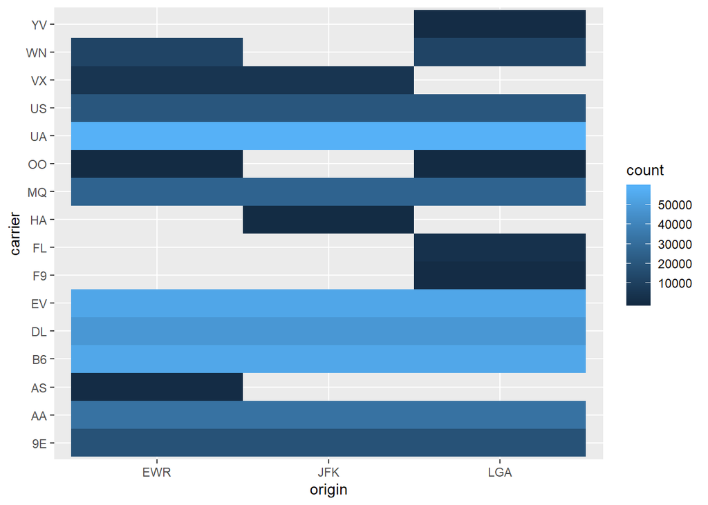

```r
flights %>%
  group_by(carrier) %>%
  mutate(count = n()) %>%
  ungroup() %>%
  select(carrier, origin, count) %>%
  ggplot(aes(x = origin, y = carrier, fill = count))+
  geom_tile(stat = "bin2d")
```

Instead of `stat = "bin2d"` you can also use a `count()` after `flights`.

Resources:

- Chapter 13 of r4ds, https://r4ds.had.co.nz/relational-data.html